# Where Is My Nearest Grill’d?

Maps and analysis to help Grill’d head office decide where to open their next franchise, without cannibalising existing stores.

Durand Sinclair

2021-02-10

[figure not shown]

Image: A hamburger, earlier today. Source: [Grill’d website](https://www.grilld.com.au/restaurants/new-south-wales/sydney)

### Business Understanding

Grill’d are a high-end hamburger restaurant that specialise in healthy burgers. Having opened their first store in [Victoria in 2004](https://www.grilld.com.au/about), by February 2021 they have grown to [147](https://www.grilld.com.au/locations) stores across Australia. Their growth strategy has been based on [selling franchises](https://www.grilld.com.au/own-a-grilld), and they use independent property consultants to pick locations.

There are two complementary challenges about picking a location. First, how do you find a location where people will want to eat your burgers. And second, how do you make sure your new location won’t cannibalise sales from your existing stores?

It is the second problem that we will tackle today. We’ll color-code all of Sydney based on how far away any given point is from the nearest existing store. That way, head office will know which locations to rule out because they’re too close to existing stores, and which locations they can investigate further.

### Data Understanding

First, we need to understand where the existing restaurants are.

I scraped Sydney restaurant locations from the Grill’d website, and then geocoded it, which involves asking Google Cloud to figure out the latitude and longitude for the locations provided. The script can be found here.

Here’s a table of the Sydney restaurants.

| id | name | address...2 | phone | city | lon | lat | address...7 |
| --- | --- | --- | --- | --- | --- | --- | --- |
| 1 | Grill'd Bondi Junction | 9-13 Bronte Rd, BONDI JUNCTION 2022 | 9387 6666 | Sydney | 151.2494992 | -33.8929936 | 9-13 bronte rd, bondi junction nsw 2022, australia |
| 2 | Grill'd Broadway | Shop 217 Broadway Shopping Centre, BROADWAY 2007 | 9211 1085 | Sydney | 151.1941253 | -33.8834035 | shop 217/1 bay st, ultimo nsw 2007, australia |
| 3 | Grill'd Chatswood | Shop 7 The Concourse, CHATSWOOD 2067 | 9411 4267 | Sydney | 151.1835533 | -33.7959507 | shop 7 the concourse, 405-419 victoria ave, chatswood nsw 2067, australia |
| 4 | Grill'd Crows Nest | 57 Willoughby Rd, CROWS NEST 2065 | 9436 0699 | Sydney | 151.2009818 | -33.8258976 | 57 willoughby rd, crows nest nsw 2065, australia |
| 5 | Grill'd Darlinghurst | 241 Crown St, DARLINGHURST 2010 | 9380 4800 | Sydney | 151.2150083 | -33.8795403 | 241 crown st, darlinghurst nsw 2010, australia |
| 6 | Grill'd Dee Why | Shop 10-11, Corner Howard Ave & PIttwater Rd, DEE WHY 2099 | 9188 8396 | Sydney | 151.2875319 | -33.7534243 | shop 10-1 corner howard ave &, pittwater rd, dee why nsw 2099, australia |
| 7 | Grill'd Galeries | The Galeries, SYDNEY 2000 | 9264 9566 | Sydney | 151.2075807 | -33.8724051 | the galeries, 500 george st, sydney nsw 2000, australia |
| 8 | Grill'd Kirrawee | 580 Princes Hwy, KIRRAWEE 2232 | 8058 9600 | Sydney | 151.0729905 | -34.0336049 | south village, shop g07/580 princes hwy, kirrawee nsw 2232, australia |
| 9 | Grill'd Leichhardt | Shop TO28 Norton Plaza, LEICHHARDT 2040 | 95509499 | Sydney | 151.1574558 | -33.8858258 | shop to28 norton plaza, 55 norton st, leichhardt nsw 2040, australia |
| 10 | Grill'd MacArthur Square | 200 Gilchrist Dr, CAMPBELLTOWN 2560 | 4625 3500 | Sydney | 150.7976599 | -34.0733804 | 200 gilchrist dr, campbelltown nsw 2560, australia |

[output cut: 9 more lines]

There are 19 stores in Sydney. Let’s locate them on a map.

[interactive chart not shown]

From a quick scan, we can see that most restaurants are located around the CBD, although there are a few others scattered across the suburbs.

### Measuring Distances

To figure out where to place the next store so it won’t get in the way of the existing stores, we want to measure the distance from the existing stores to various other points on the map. So we’re going to need to do two things:

1. Use A Grid System - It’s no good to measure the distance from a store to “various points”. We have to define what those points are. So let’s cut the map into squares, and measure the distance from each store to the middle of those squares.
2. Use The Right Co-ordinate Reference System - When we have a city as large as Sydney, the distance between two points is thrown off by the curvature of the Earth. To get the distances right, we have to make the Earth flat first. We can do this by changing the co-ordinate reference system we draw our map on.

Let’s create our grid:

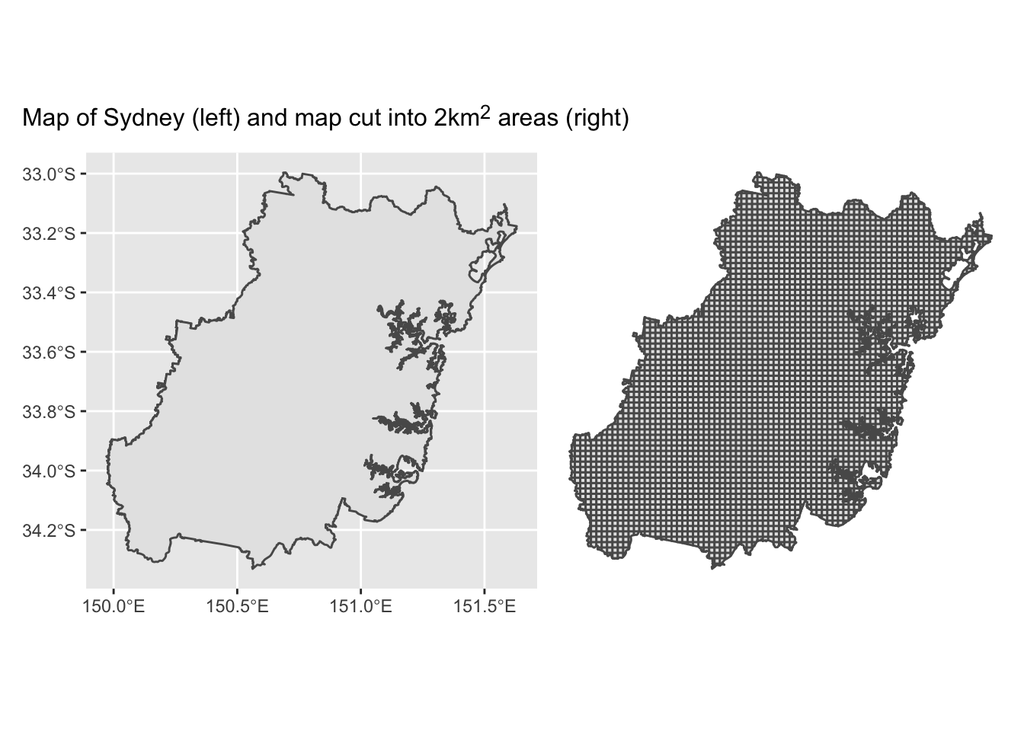

On the left you can see the map of Sydney, and on the right is the map after we cut it into 2km squares. Now we can measure the distance from the centre of each grid square to the nearest restaurant.

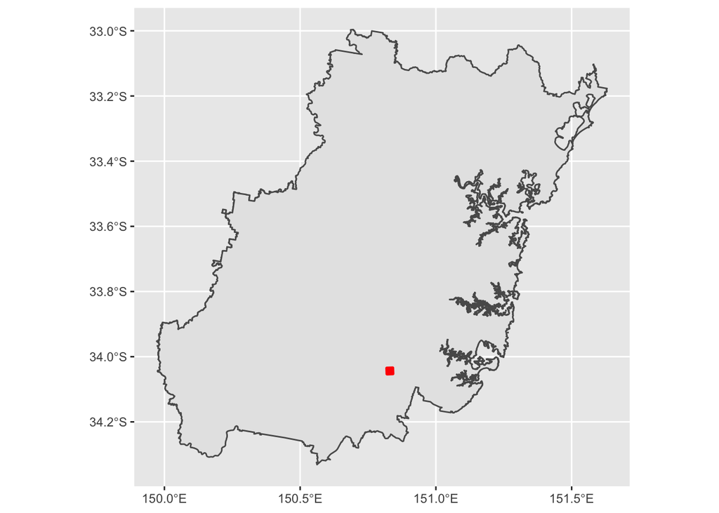

Now let’s add some of the nearby restaurants.

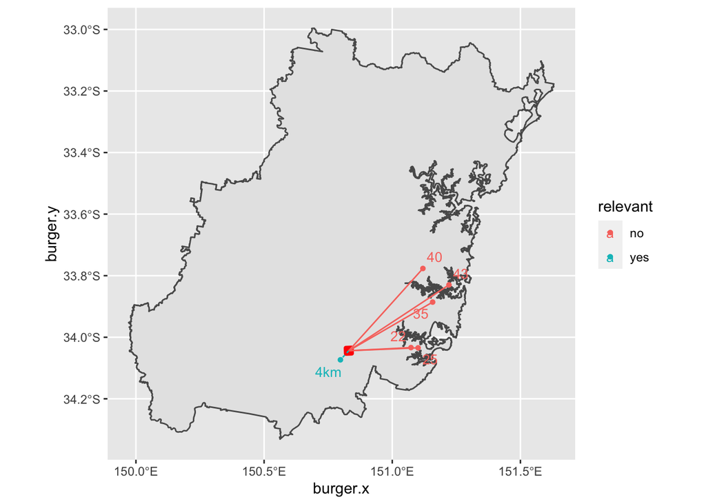